# 3.0.9. EXTRA LightGBM con Pipeline

## 3.0.9. LIGHTGBM con PIPELINE

Queremos volver a realizar el modelo LightGBM con Pipelines de cara a la segunda práctica de la asignatura. Como ya hemos comentado en notebooks anteriores, el LightGBM es el modelo que mejor se adapta tanto en tiempo de ejecución como en predicción a el problema planteado de los accidentes de tráfico mortales.

En este sentido vamos a tener que cambiar nuestro planteamiento de codificación en dos variables `ver mas adelante`. Por lo que puede que varie un poco en el resultado, (acabaremos concluyendo cuanto es su variación si varía).

Nuestro objetivo con esta plantilla, es elaborar el mismo modelo, con los mismos parámetros ya establecidos en el `notebook 3.0.5.` Pero, adaptado a los datos que vamos a introducir en el formato json. Es decir, que incluya la transformación.

Tal y como habiamos planificado nuestro trabajo, los modelos no podían leer datos como "lluvia", "asfalto mojado", "choque frontal" sino que leen numeros decimales. Como en una situación normal una persona no va a saber que para nuestro modelo la lluvia es 0.0123... Hemos introducido con los pipelines el preprocesamiento en el propio modelo. Sin embargo, hay una parte del preprocesamiento del `notebook 2.0.3.` que no hemos introducido. Se trata de las variables `c_vehs` y `c_hour`. En el `notebook 2.0.3` cambiamos todos los valores desconocidos por valores extremos con el método resample. Sin embargo, aqui vamos a imputar los valores por el método `Simple Imputer` con la mediana como valor escogido.

#### Importo Librerias

```python
import warnings
warnings.filterwarnings('ignore')
```

```python
import pandas as pd
import pyarrow.csv as pv
import pyarrow.parquet as pq
import seaborn as sns
import numpy as np
from matplotlib import pyplot as plt
from matplotlib import pyplot
from sklearn import preprocessing
from sklearn.impute import SimpleImputer
import pandas as pd
import pyarrow.csv as pv
import pyarrow.parquet as pq
import seaborn as sns
from sklearn.tree import DecisionTreeClassifier
from sklearn import metrics
from sklearn.preprocessing import StandardScaler
from sklearn.compose import ColumnTransformer
from sklearn.model_selection import train_test_split
from sklearn.preprocessing import LabelEncoder
from sklearn.preprocessing import StandardScaler
from sklearn.preprocessing import RobustScaler
import category_encoders as ce
from sklearn.utils import resample
from sklearn.metrics import classification_report, confusion_matrix, roc_curve, auc, \
                            silhouette_score, recall_score, precision_score, make_scorer, \
                            roc_auc_score, f1_score, precision_recall_curve
from sklearn.metrics import accuracy_score, roc_auc_score, \
                            classification_report, confusion_matrix
from sklearn.metrics import plot_confusion_matrix
from sklearn import tree
from sklearn.model_selection import GridSearchCV, RandomizedSearchCV
from sklearn.metrics import fbeta_score
from sklearn.model_selection import cross_val_score
from sklearn.model_selection import RepeatedStratifiedKFold
from lightgbm import LGBMClassifier
import lightgbm as lgb
import time
import pickle
import scikitplot as skplt
from sklearn.pipeline import Pipeline
```

#### Importamos funciones:

```python
def classify_metrics(modelo, x_test, y_test, predict):

    '''Imprimimos el reporte de clasificación:  '''

    print("Classification Report")
    print(classification_report(y_test, predict))

    '''Imprimimos el Accuracy: '''
    print("Accuracy:", metrics.accuracy_score(y_test, predict))

    '''Imprimimos el F1-score'''
    print("F1-Score:", metrics.f1_score(y_test, predict))

    print("---")

    '''Matriz de confusión: '''
    titles_options = [("Confusion matrix, without normalization", None),
                  ("Normalized confusion matrix", 'true')]
    for title, normalize in titles_options:
        disp = plot_confusion_matrix(modelo, x_test, y_test,
                                     display_labels=["mortal", "no mortal"],
                                     cmap=plt.cm.Blues,
                                     normalize=normalize)
        disp.ax_.set_title(title)

        print(title)
        print(disp.confusion_matrix)

    plt.show()

    yhat = modelo.predict_proba(x_test)
    pos_pred = yhat[:,1]

    # calculate roc curves
    fpr, tpr, thresholds = roc_curve(y_test, pos_pred)
    # plot the roc curve for the model
    plt.plot([0,1], [0,1], linestyle='--', label='No Skill')
    plt.plot(fpr, tpr, marker='.', label='Random Forest')
    # axis labels
    plt.xlabel('False Positive Rate')
    plt.ylabel('True Positive Rate')
    plt.legend()
    # show the plot
    plt.show()


    # calculate the g-mean for each threshold
    gmeans = np.sqrt(tpr * (1-fpr))

    # locate the index of the largest g-mean
    ix = np.argmax(gmeans)
    print('Best Threshold=%f, G-Mean=%.3f' % (thresholds[ix], gmeans[ix]))

    '''Dibujando la curva ROC: '''
    print("CURVA ROC con THRESHOLD:")
    # plot the roc curve for the model
    plt.plot([0,1], [0,1], linestyle='--', label='No Skill')
    plt.plot(fpr, tpr, marker='.', label='Modelo')
    plt.scatter(fpr[ix], tpr[ix], s=100, marker='o', color='black', label='Best')
    # axis labels
    plt.xlabel('False Positive Rate')
    plt.ylabel('True Positive Rate')
    plt.legend()
    # show the plot
    plt.show()

    '''Calculando el area AUC: '''
    print("AREA AUC: ")
    # calculate roc auc
    roc_auc = roc_auc_score(y_test, pos_pred)
    print('ROC AUC %.3f' % roc_auc)

    '''Calculamos la curva pr: '''
    # calculate pr-curve
    precision, recall, thresholds = precision_recall_curve(y_test, pos_pred)
    print("PRECISSION/RECALL CURVE: ")
    # plot the roc curve for the model
    no_skill = len(y_test[y_test==1]) / len(y_test)
    plt.plot([0,1], [no_skill,no_skill], linestyle='--', label='No Skill')
    plt.plot(recall, precision, marker='.', label='model')
    # axis labels
    plt.xlabel('Recall')
    plt.ylabel('Precision')
    plt.legend()
    # show the plot
    plt.show()

    '''Cumulative Gain Curve: '''
    skplt.metrics.plot_cumulative_gain(y_test, yhat)
    plt.show()

    '''Lift Curve:'''
    skplt.metrics.plot_lift_curve(y_test, yhat)
    plt.show()
```

#### Importo el dataset guardado en el preprocesing [`2.0.2.`](http://localhost:8888/notebooks/Desktop/CUNEF/Practica%20Machine%20Learning/project_template/notebooks/2.0.2.%20Preprocesing.%20Analisis%20de%20las%20variables.%20.ipynb)

```python
df_acc = pd.read_parquet('../data/df_acc_1.parquet')
df_acc.columns = df_acc.columns.map(lambda x: x[:].lower())
df_acc
```

|  | c_year | c_mnth | c_wday | c_hour | c_sev | c_vehs | c_conf | c_rcfg | c_wthr | c_rsur | c_raln | c_traf | c_nums |
| --- | --- | --- | --- | --- | --- | --- | --- | --- | --- | --- | --- | --- | --- |
| 0 | 1999 | 01 | 1 | 00 | 2 | 01 | 01 | 01 | 1 | 4 | 1 | 18 | 1 |
| 1 | 1999 | 01 | 1 | 00 | 2 | 01 | 01 | 01 | 1 | 5 | 1 | 18 | 1 |
| 2 | 1999 | 01 | 1 | 00 | 2 | 01 | 01 | 01 | 2 | 1 | 1 | 18 | 1 |
| 3 | 1999 | 01 | 1 | 00 | 2 | 01 | 01 | 01 | 6 | 3 | 2 | 18 | 2 |
| 4 | 1999 | 01 | 1 | 00 | 2 | 01 | 01 | UU | 1 | 2 | 3 | 18 | 1 |
| ... | ... | ... | ... | ... | ... | ... | ... | ... | ... | ... | ... | ... | ... |
| 1850312 | 2014 | 12 | 7 | UU | 2 | 02 | UU | 02 | U | U | 1 | 03 | 2 |
| 1850313 | 2014 | UU | U | 14 | 2 | 01 | 02 | 01 | 1 | 5 | 4 | 18 | 1 |
| 1850314 | 2014 | UU | U | 22 | 1 | 01 | 06 | 01 | 2 | 4 | Q | 18 | 2 |
| 1850315 | 2014 | UU | U | 23 | 2 | 01 | 06 | 05 | 1 | 1 | U | 18 | 1 |
| 1850316 | 2014 | UU | U | UU | 2 | UU | UU | 01 | U | U | U | UU | 20 |

1850317 rows × 13 columns

#### SPLIT (train y test)

```python
'''Transformación variable objetivo, no la metemos en el pipeline: '''
df_acc["c_sev"] = preprocessing.LabelEncoder().fit_transform(df_acc[["c_sev"]])

'''Train y test: '''
X = df_acc.drop("c_sev", axis=1)
Y = df_acc["c_sev"]
x_train, x_test, y_train, y_test = train_test_split(X, Y, stratify=Y, test_size=0.25, random_state=1422)
'''juntamos en train y test: '''
x_train_t = pd.concat([x_train, y_train], axis=1)
x_test_t = pd.concat([x_test, y_test], axis=1)
```

#### Undersampling

```python
'''Diferenciamos mortalidad de no mortalidad: '''
muestra_minoritaria = x_train_t[(x_train_t.c_sev == 0)]
muestra_mayoritaria = x_train_t[(x_train_t.c_sev == 1)]

'''muestra reducida con random undersample: '''

muestra_mayoritaria_reducida = resample(muestra_mayoritaria, replace=True, n_samples=40320, random_state=1234)

x_train = pd.concat([muestra_mayoritaria_reducida, muestra_minoritaria]).reset_index().drop('index', axis=1)
y_train = x_train['c_sev']
```

**En este punto ya tenemos nuestra muestra de train simplemente con el undersampling realizado, en el notebook 2.0.3. si hubieramos querido hacer pipeline en todos nuestros modelos tendríamos que haber guardado el train y test aquí.**

Antes de empezar con el modelo, queremos abordar un problema con el que nos hemos topado. Resulta que en pipeline, no hemos hallado ninguna manera de reeemplazar los valores "U", "UU", "" por NA o por valores extremos tal y como teníamos planeado en el notebook 2.0.3. En este sentido, vamos a cambiar nuestra estrategia de codificación, se verán afectadas las siguientes variables:

- `c_vehs`: La variable de coches involucrados, en vez de poner un valor extremo (99) vamos a introducir el valor de la mediana. Creemos que esto no va a afectar a la mediana, puesto que el valor de la mediana sigue siendo un valor extremo en esta distribución.
- `c_hour`: Cambiar el valor de la hora 24 a un valor de la mediana no cambiará la distribución de la variable y por lo tanto, no afectará al modelo.

Procedemos a codificar los valores "UU", "U" y "" de las variables `c_vehs`, `c_hour`, `c_wday`y `c_mnth` como variables na para asi poderles introducir el simpleImputer como preprocesador de valores na.

```python
columns_with_na = x_train[["c_vehs", "c_hour", "c_wday", "c_mnth"]].columns
```

```python
for i in x_train[columns_with_na]:
    x_train[i] = x_train[i].replace("UU", np.nan)
    x_train[i] = x_train[i].replace("U", np.nan)
    x_train[i] = x_train[i].replace("", np.nan)
```

```python
for i in x_test_t[columns_with_na]:
    x_test_t[i] = x_test_t[i].replace("UU", np.nan)
    x_test_t[i] = x_test_t[i].replace("U", np.nan)
    x_test_t[i] = x_test_t[i].replace("", np.nan)
```

```python
x_test = x_test_t.drop('c_sev',axis=1)
y_test = x_test_t['c_sev']
```

Queremos dividir las columnas en función de sus diferentes modos de planteamiento del procesamiento:

```python
columns_for_robust = x_train[["c_nums","c_vehs"]].columns
columns_for_just_simpleimputer = x_train[["c_hour", "c_wday", "c_mnth"]].columns
columns_for_woe = x_train[["c_conf", "c_rcfg", "c_wthr", "c_rsur", "c_raln", "c_traf"]].columns
```

#### Definimos Pipelines:

```python
numeric_transformer = Pipeline(steps=[
    ('imputer', SimpleImputer(strategy='median')),
    ('robust', RobustScaler())])

just_simpleimputer = Pipeline(steps=[
    ('imputer', SimpleImputer(strategy='median'))])

woe = Pipeline(steps=[
    ('woe', ce.WOEEncoder())
])
```

```python
preprocessor = ColumnTransformer(
    transformers=[
        ('num', numeric_transformer, columns_for_robust),
        ('simpleimputer',just_simpleimputer,columns_for_just_simpleimputer),
        ('woe',woe,columns_for_woe)])
```

```python
classifier = LGBMClassifier(objective='binary',alpha=1, scale_pos_weight=0.61,
                            boosting_type="gbdt", learning_rate=0.1, max_depth=3,
                            num_leaves=6)

pipe = Pipeline(steps=[('preprocessor', preprocessor),
                       ('classifier', classifier)])
```

```python
%%time
start = time.time()
model5_with_pipeline = pipe.fit(x_train, y_train)
end = time.time()
y_pred = model5_with_pipeline.predict(x_test)
print(y_pred)
print("tiempo de ejecución del fit: ", end - start)
```

```
[1 1 0 ... 1 1 0]
tiempo de ejecución del fit:  0.42447710037231445
Wall time: 1.28 s
```

#### Metricas:

```
Classification Report
              precision    recall  f1-score   support

           0       0.04      0.72      0.08      8960
           1       0.99      0.66      0.79    453620

    accuracy                           0.66    462580
   macro avg       0.52      0.69      0.43    462580
weighted avg       0.97      0.66      0.78    462580

Accuracy: 0.6584525919840892
F1-Score: 0.7905166115753981
---
Confusion matrix, without normalization
[[  6482   2478]
 [155515 298105]]
Normalized confusion matrix
[[0.7234375 0.2765625]
 [0.342831  0.657169 ]]
```

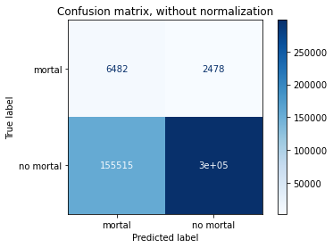

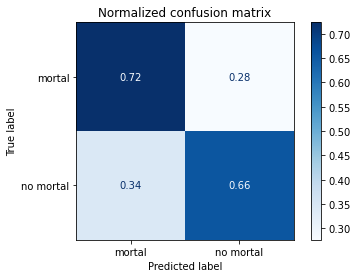

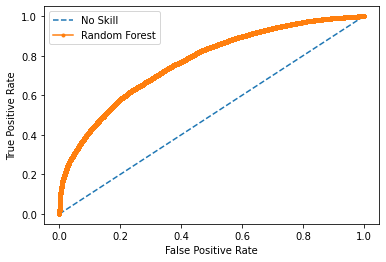

```
Best Threshold=0.495183, G-Mean=0.691
CURVA ROC con THRESHOLD:
```

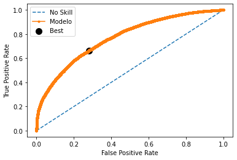

```
AREA AUC:
ROC AUC 0.769
PRECISSION/RECALL CURVE:
```

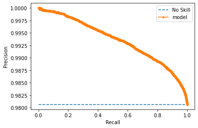

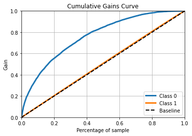

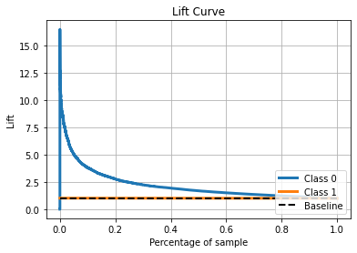

```python
classify_metrics(model5_with_pipeline, x_test, y_test,y_pred)
```

#### Comentarios:

Como se puede observar en las métricas, el cambio que hemos realizado en el preprocesamiento de `c_hour`y `c_vehs`no ha afectado de manera excesiva, de hecho, nos ha mejorado las predicciones en un punto porcentual.

#### Guardamos el modelo en pickle

```python
filename = '../models/model5def_pipeline.sav'
pickle.dump(model5_with_pipeline, open(filename, 'wb'))
```